# Thesis Workflow

Neil Kester

4/15/2021

# Preparation

## Create a Simulation and Entity Table

First, it is useful to understand information about the sensors and the entities that carried them in the specific “Design Point” and “Iteration” under evaluation. First, lets load the required query and connection object information and then execute the function.

```r
source("./connectionObjects/entityMappingConnectionObj.R")

entitySensorMapping <- modSim::mapSensorsAndEntities(mongoUri = mongoUri,
                              mongoDb = mongoDb,
                              mongoCollection = sensorIDNameCollection,
                              mongoFields = sensorIDNameFields,
                              mongoQuery = sensorIDNameQuery)
```

```
## Working on column: state
```

```
## Working on column: status
```

### Sensory Description

```r
entitySensorMapping$SensorDescription
```

```
## # A tibble: 30 x 3
##    sensorId                             acquireSensorType        magnification
##    <chr>                                <chr>                    <chr>
##  1 6ef0c641-6693-46ad-943b-203a7792d849 tankDaySight_sensor      FOV_W
##  2 b4b94b73-5a4d-4a53-a73d-13d70259a895 7x50Bino_sensor          FOV_S
##  3 f9421687-36ca-4f5e-9993-481d7de7f0f2 CdrLdrVisionBlock_sensor FOV_S
##  4 c96a7fe4-8d17-40f0-ada0-b92f7c713cfa tankDaySight_sensor      FOV_W
##  5 a826c760-8121-412a-a865-82dd1341a4b0 7x50Bino_sensor          FOV_S
##  6 d49c94fa-c76a-4ba9-b74f-528436a43c55 CdrLdrVisionBlock_sensor FOV_S
##  7 5f32bf10-054e-4204-8184-c2d0c5a530ce heloDaySight_sensor      FOV_W
##  8 0e79e63f-5bfb-4522-8ead-deedf025b479 7x50Bino_sensor          FOV_S
##  9 f5c75e3f-4de2-48c2-b824-f57ae953f867 unaidedEye_sensor        FOV_S
## 10 f23a9fc9-c291-4b9f-babe-1d151ce625e3 heloDaySight_sensor      FOV_W
## # … with 20 more rows
```

### Entity ID to Entity Name

```r
entitySensorMapping$EntityIdToName
```

```
## # A tibble: 15 x 2
##    entityId                   source
##    <chr>                      <chr>
##  1 164684be-2368-405a-b11f-3… BLUEFORCE/BLUEFORCE/1.MECHBN/15.RECCECOY/151.RECC…
##  2 71bd950b-70ab-493c-8bfd-0… BLUEFORCE/BLUEFORCE/1.MECHBN/15.RECCECOY/151.RECC…
##  3 2a1f2f19-fd75-43af-940e-7… BLUEFORCE/BLUEFORCE/1.MECHBN/15.RECCECOY/151.RECC…
##  4 0e95015f-006e-448b-9431-7… BLUEFORCE/BLUEFORCE/1.MECHBN/15.RECCECOY/151.RECC…
##  5 d4aa2300-ceee-4677-acaa-9… BLUEFORCE/BLUEFORCE/1.MECHBN/15.RECCECOY/151.RECC…
##  6 31fe0957-0ba8-4a73-8470-5… BLUEFORCE/BLUEFORCE/1.MECHBN/15.RECCECOY/15.RADIO…
##  7 a364afbc-e0fb-4d0a-a8bd-7… REDFORCE/REDFORCE/1.MLRSBTY/BM30 6
##  8 23a15820-4a7a-4e2d-ad6a-7… REDFORCE/REDFORCE/1.MLRSBTY/BM30 1
##  9 fc58e557-f4ad-4353-a186-1… REDFORCE/REDFORCE/1.MLRSBTY/BM30 5
## 10 22d3b6e3-732d-4e69-982e-9… REDFORCE/REDFORCE/1.EW/JAMMER 1
## 11 11dc4f05-80b6-4f5c-a14a-7… REDFORCE/REDFORCE/1.MLRSBTY/BM30 3
## 12 aefaa978-c4f5-42ca-bd7f-9… BLUEFORCE/BLUEFORCE/1.MECHBN/1.MECHBN CDR
## 13 5c1c0ee5-d703-4b8a-ab5a-5… REDFORCE/REDFORCE/1.MLRSBTY/BM30 2
## 14 a8cfb96c-e7f8-4b7c-9784-0… REDFORCE/REDFORCE/1.MLRSBTY/BM30 4
## 15 0d14b64f-4301-4872-b188-e… BLUEFORCE/BLUEFORCE/1.MECHBN/15.RECCECOY/15.RECCE…
```

### Sensor ID to Entity ID

```r
entitySensorMapping$SensorToEntityId
```

```
## # A tibble: 30 x 2
##    sensorId                             entityId
##    <chr>                                <chr>
##  1 6ef0c641-6693-46ad-943b-203a7792d849 164684be-2368-405a-b11f-327d41a58665
##  2 b4b94b73-5a4d-4a53-a73d-13d70259a895 164684be-2368-405a-b11f-327d41a58665
##  3 f9421687-36ca-4f5e-9993-481d7de7f0f2 164684be-2368-405a-b11f-327d41a58665
##  4 c96a7fe4-8d17-40f0-ada0-b92f7c713cfa 71bd950b-70ab-493c-8bfd-0f2060886a83
##  5 a826c760-8121-412a-a865-82dd1341a4b0 71bd950b-70ab-493c-8bfd-0f2060886a83
##  6 d49c94fa-c76a-4ba9-b74f-528436a43c55 71bd950b-70ab-493c-8bfd-0f2060886a83
##  7 5f32bf10-054e-4204-8184-c2d0c5a530ce 2a1f2f19-fd75-43af-940e-7b8c560ed463
##  8 0e79e63f-5bfb-4522-8ead-deedf025b479 0e95015f-006e-448b-9431-72bf660f0edd
##  9 f5c75e3f-4de2-48c2-b824-f57ae953f867 0e95015f-006e-448b-9431-72bf660f0edd
## 10 f23a9fc9-c291-4b9f-babe-1d151ce625e3 d4aa2300-ceee-4677-acaa-9d43c078cff9
## # … with 20 more rows
```

### Unnested Sensor State

This is the full data set produced by the input query.

```r
entitySensorMapping$UnnestedSensorState
```

```
## # A tibble: 492 x 11
##    `_id`   runId    runTime   designPoint  iteration  time sensorId   entityId
##    <chr>   <chr>    <chr>     <chr>            <int> <int> <chr>      <chr>
##  1 606dbf… 419cd16… 2021-04-… Test baseli…    1.74e9     0 6ef0c641-… 164684be-…
##  2 606dbf… 419cd16… 2021-04-… Test baseli…    1.74e9     0 b4b94b73-… 164684be-…
##  3 606dbf… 419cd16… 2021-04-… Test baseli…    1.74e9     0 f9421687-… 164684be-…
##  4 606dbf… 419cd16… 2021-04-… Test baseli…    1.74e9     0 c96a7fe4-… 71bd950b-…
##  5 606dbf… 419cd16… 2021-04-… Test baseli…    1.74e9     0 a826c760-… 71bd950b-…
##  6 606dbf… 419cd16… 2021-04-… Test baseli…    1.74e9     0 d49c94fa-… 71bd950b-…
##  7 606dbf… 419cd16… 2021-04-… Test baseli…    1.74e9     0 5f32bf10-… 2a1f2f19-…
##  8 606dbf… 419cd16… 2021-04-… Test baseli…    1.74e9     0 0e79e63f-… 0e95015f-…
##  9 606dbf… 419cd16… 2021-04-… Test baseli…    1.74e9     0 f5c75e3f-… 0e95015f-…
## 10 606dbf… 419cd16… 2021-04-… Test baseli…    1.74e9     0 f23a9fc9-… d4aa2300-…
## # … with 482 more rows, and 3 more variables: acquireSensorType <chr>,
## #   magnification <chr>, source <chr>
```

## Create a Line of Sight Table

This table describes when a sensor target has Line of Sight (LOS). This does not mean they have acquired each other but rather that their line of sight is not obstructed.

```r
source("./connectionObjects/hasLosConnectionObj.R")

LosData <- modSim::mongoUnnest(mongoUri = mongoUri,
                               mongoDb = mongoDb,
                               mongoCollection = losMongoCollection,
                               mongoQuery = losMongoQuery,
                               mongoFields = losMongoFields,
                               unnestCols = "event")
```

```
## Working on column: event
```

```r
LosData
```

```
## # A tibble: 951 x 16
##    `_id`   runId    runTime   designPoint  iteration  time sensorId   targetId
##    <chr>   <chr>    <chr>     <chr>            <int> <int> <chr>      <chr>
##  1 606dbf… 419cd16… 2021-04-… Test baseli…    1.74e9    10 3172ca97-… 11dc4f05-…
##  2 606dbf… 419cd16… 2021-04-… Test baseli…    1.74e9    10 a55c0600-… 5c1c0ee5-…
##  3 606dbf… 419cd16… 2021-04-… Test baseli…    1.74e9    10 f9421687-… 71bd950b-…
##  4 606dbf… 419cd16… 2021-04-… Test baseli…    1.74e9    10 6ef0c641-… d4aa2300-…
##  5 606dbf… 419cd16… 2021-04-… Test baseli…    1.74e9    10 a826c760-… d4aa2300-…
##  6 606dbf… 419cd16… 2021-04-… Test baseli…    1.74e9    10 5f4cbbb3-… 11dc4f05-…
##  7 606dbf… 419cd16… 2021-04-… Test baseli…    1.74e9    10 3172ca97-… a364afbc-…
##  8 606dbf… 419cd16… 2021-04-… Test baseli…    1.74e9    10 4fb30d1d-… aefaa978-…
##  9 606dbf… 419cd16… 2021-04-… Test baseli…    1.74e9    10 7d05191d-… 22d3b6e3-…
## 10 606dbf… 419cd16… 2021-04-… Test baseli…    1.74e9    10 c96a7fe4-… 2a1f2f19-…
## # … with 941 more rows, and 8 more variables: changeNumber <int>, hasLOS <lgl>,
## #   hasLOSUpdateTime <dbl>, characteristicDimension <dbl>,
## #   characteristicDimensionUpdateTime <dbl>, background <chr>,
## #   backgroundUpdateTime <dbl>, nextUpdateTime <dbl>
```

## Sensor Target Acquisitions

Unlike the LOS table, this table shows the state of acquisition between each sensor target pair. It also shows the previous acquisition state so we can determine when the acquistion level changes.

```r
source("./connectionObjects/acqConnectionObj.R")

sensorAcq <- modSim::sensorAcquisition(mongoUri = mongoUri,
                          mongoDb = mongoDb,
                          mongoCollection = acqMongoCollection,
                          mongoQuery = acqMongoQuery,
                          mongoFields = acqMongoFields,
                          recursiveUnnests = c("event",
                                               "messageData",
                                               "any",
                                               "sensorDetection"))
```

```
## Working on column: event
```

```
## Working on column: messageData
```

```
## Working on column: any
```

```
## Working on column: sensorDetection
```

# Compile Tables

Using the reference tables created in last section, we will transform them into useful information.

## Sensing Entities

I only care about Entities (vehicles) that have sensors so I’ll drop all entities not in the `SensorToEntityId` table. Then I’ll add the description of each sensor and reorder the columns.

```r
requireNamespace("magrittr")

humanNameToSensor <- dplyr::left_join(x = entitySensorMapping$EntityIdToName,
                                      y = entitySensorMapping$SensorToEntityId,
                                      by = "entityId") %>%
  dplyr::left_join(x = .,
                   y = entitySensorMapping$SensorDescription,
                   by = "sensorId") %>%
  dplyr::mutate(pltLevelName = stringr::str_extract(string = source,
                                                 pattern = "[^/]*/[^/]*/[^/]*$"),
                shortName =  stringr::str_extract(string = source,
                                                 pattern = "[^/]*$")) %>%
  dplyr::select(shortName,
                pltLevelName,
                acquireSensorType,
                magnification,
                entityId,
                sensorId,
                source)

humanNameToSensor
```

```
## # A tibble: 30 x 7
##    shortName  pltLevelName   acquireSensorType magnification entityId  sensorId
##    <chr>      <chr>          <chr>             <chr>         <chr>     <chr>
##  1 EPBV 90 2  151.RECCEPLT/… tankDaySight_sen… FOV_W         164684be… 6ef0c641…
##  2 EPBV 90 2  151.RECCEPLT/… 7x50Bino_sensor   FOV_S         164684be… b4b94b73…
##  3 EPBV 90 2  151.RECCEPLT/… CdrLdrVisionBloc… FOV_S         164684be… f9421687…
##  4 EPBV 90 1  151.RECCEPLT/… tankDaySight_sen… FOV_W         71bd950b… c96a7fe4…
##  5 EPBV 90 1  151.RECCEPLT/… 7x50Bino_sensor   FOV_S         71bd950b… a826c760…
##  6 EPBV 90 1  151.RECCEPLT/… CdrLdrVisionBloc… FOV_S         71bd950b… d49c94fa…
##  7 WASP 1     151.RECCEPLT/… heloDaySight_sen… FOV_W         2a1f2f19… 5f32bf10…
##  8 151.RECCE… 15.RECCECOY/1… 7x50Bino_sensor   FOV_S         0e95015f… 0e79e63f…
##  9 151.RECCE… 15.RECCECOY/1… unaidedEye_sensor FOV_S         0e95015f… f5c75e3f…
## 10 WASP 2     151.RECCEPLT/… heloDaySight_sen… FOV_W         d4aa2300… f23a9fc9…
## # … with 20 more rows, and 1 more variable: source <chr>
```

Now that I understand the entities and their sensors, I’ll select one entity at a time, starting with `EPBV 90 2`.

```r
entity_epbv_90_2 <- humanNameToSensor %>%
  dplyr::filter(shortName == "EPBV 90 2")

entity_epbv_90_2
```

```
## # A tibble: 3 x 7
##   shortName pltLevelName acquireSensorTy… magnification entityId sensorId source
##   <chr>     <chr>        <chr>            <chr>         <chr>    <chr>    <chr>
## 1 EPBV 90 2 151.RECCEPL… tankDaySight_se… FOV_W         164684b… 6ef0c64… BLUEF…
## 2 EPBV 90 2 151.RECCEPL… 7x50Bino_sensor  FOV_S         164684b… b4b94b7… BLUEF…
## 3 EPBV 90 2 151.RECCEPL… CdrLdrVisionBlo… FOV_S         164684b… f942168… BLUEF…
```

# Produce LOS by Sensor - Target Pair

## What Can EPBV 90 2 See Over Time

First, lets look at what LOS EPBV 90 2 has for each target over time. I’ll select only the columns of information I need and filter out all sensors except those on the `EPBV 90 2` platform.

```r
entity_epbv_90_2_los <- LosData %>%
  dplyr::select(sensorId,targetId,time,hasLOS) %>%
  dplyr::filter(sensorId %in% entity_epbv_90_2$sensorId)


entity_epbv_90_2_los
```

```
## # A tibble: 90 x 4
##    sensorId                         targetId                         time hasLOS
##    <chr>                            <chr>                           <int> <lgl>
##  1 f9421687-36ca-4f5e-9993-481d7de… 71bd950b-70ab-493c-8bfd-0f2060…    10 TRUE
##  2 6ef0c641-6693-46ad-943b-203a779… d4aa2300-ceee-4677-acaa-9d43c0…    10 TRUE
##  3 f9421687-36ca-4f5e-9993-481d7de… 2a1f2f19-fd75-43af-940e-7b8c56…    10 TRUE
##  4 b4b94b73-5a4d-4a53-a73d-13d7025… 0e95015f-006e-448b-9431-72bf66…    10 TRUE
##  5 b4b94b73-5a4d-4a53-a73d-13d7025… 164684be-2368-405a-b11f-327d41…    10 TRUE
##  6 f9421687-36ca-4f5e-9993-481d7de… 0e95015f-006e-448b-9431-72bf66…    10 TRUE
##  7 6ef0c641-6693-46ad-943b-203a779… 0e95015f-006e-448b-9431-72bf66…    10 TRUE
##  8 6ef0c641-6693-46ad-943b-203a779… 2a1f2f19-fd75-43af-940e-7b8c56…    10 TRUE
##  9 f9421687-36ca-4f5e-9993-481d7de… d4aa2300-ceee-4677-acaa-9d43c0…    10 TRUE
## 10 6ef0c641-6693-46ad-943b-203a779… 164684be-2368-405a-b11f-327d41…    10 TRUE
## # … with 80 more rows
```

That data frame looks good. Finally, I’ll filter to see if any of the sensors EVER do not have line of sight with any of the targets.

```r
entity_epbv_90_2_los %>%
    dplyr::filter(!hasLOS)
```

```
## # A tibble: 26 x 4
##    sensorId                        targetId                          time hasLOS
##    <chr>                           <chr>                            <int> <lgl>
##  1 f9421687-36ca-4f5e-9993-481d7d… 71bd950b-70ab-493c-8bfd-0f2060…  86002 FALSE
##  2 b4b94b73-5a4d-4a53-a73d-13d702… 71bd950b-70ab-493c-8bfd-0f2060…  86002 FALSE
##  3 b4b94b73-5a4d-4a53-a73d-13d702… 2a1f2f19-fd75-43af-940e-7b8c56… 154244 FALSE
##  4 6ef0c641-6693-46ad-943b-203a77… 2a1f2f19-fd75-43af-940e-7b8c56… 154244 FALSE
##  5 f9421687-36ca-4f5e-9993-481d7d… 2a1f2f19-fd75-43af-940e-7b8c56… 154244 FALSE
##  6 b4b94b73-5a4d-4a53-a73d-13d702… 2a1f2f19-fd75-43af-940e-7b8c56… 156007 FALSE
##  7 6ef0c641-6693-46ad-943b-203a77… 2a1f2f19-fd75-43af-940e-7b8c56… 156007 FALSE
##  8 f9421687-36ca-4f5e-9993-481d7d… 2a1f2f19-fd75-43af-940e-7b8c56… 156007 FALSE
##  9 f9421687-36ca-4f5e-9993-481d7d… 2a1f2f19-fd75-43af-940e-7b8c56… 157770 FALSE
## 10 6ef0c641-6693-46ad-943b-203a77… 2a1f2f19-fd75-43af-940e-7b8c56… 157770 FALSE
## # … with 16 more rows
```

It turns out that various sensors on `EPBV 90 2` do not have line of sight with several targets during this simulation.

## Start of a LOS Function!

I’ll run through all the others sensors and produce “Has LOS” and “Doesn’t Have LOS” data frames.

```r
entIds <- dplyr::distinct(humanNameToSensor,entityId)[[1]]

LosResponsesFalse <- list()

LosResponsesTrue <- list()

LosDataSubset <- LosData %>%
  dplyr::select(sensorId,targetId,time,hasLOS)

for(entId in entIds){

  testEntity <- dplyr::filter(humanNameToSensor,entityId == entId)

  LosResponsesFalse <- LosDataSubset %>%
    dplyr::filter(sensorId %in% testEntity$sensorId) %>%
    dplyr::filter(!hasLOS) %>%
    dplyr::mutate(entityId = entId) %>%
    dplyr::bind_rows(LosResponsesFalse,
                     .)

  LosResponsesTrue <- LosDataSubset %>%
    dplyr::filter(sensorId %in% testEntity$sensorId) %>%
    dplyr::filter(hasLOS) %>%
    dplyr::mutate(entityId = entId) %>%
    dplyr::bind_rows(LosResponsesTrue,
                     .)

}

LosResponsesFalse <- dplyr::select(LosResponsesFalse,
              entityId,
              sensorId,
              targetId,
              time,
              hasLOS)

LosResponsesTrue <- dplyr::select(LosResponsesTrue,
              entityId,
              sensorId,
              targetId,
              time,
              hasLOS)
```

Now we have two tidy data frames. One with those observations where the sensor does not have line of sight to a specific target and the second where it does. This data frame contains the entityId, the sensorId, and the targetId so we can get back to human readable names and characteristics of each quickly. It also has the time this event occurred and the `hasLOS` TRUE/FALSE response.

```r
LosResponsesFalse
```

```
## # A tibble: 189 x 5
##    entityId              sensorId             targetId               time hasLOS
##    <chr>                 <chr>                <chr>                 <int> <lgl>
##  1 164684be-2368-405a-b… f9421687-36ca-4f5e-… 71bd950b-70ab-493c-…  86002 FALSE
##  2 164684be-2368-405a-b… b4b94b73-5a4d-4a53-… 71bd950b-70ab-493c-…  86002 FALSE
##  3 164684be-2368-405a-b… b4b94b73-5a4d-4a53-… 2a1f2f19-fd75-43af-… 154244 FALSE
##  4 164684be-2368-405a-b… 6ef0c641-6693-46ad-… 2a1f2f19-fd75-43af-… 154244 FALSE
##  5 164684be-2368-405a-b… f9421687-36ca-4f5e-… 2a1f2f19-fd75-43af-… 154244 FALSE
##  6 164684be-2368-405a-b… b4b94b73-5a4d-4a53-… 2a1f2f19-fd75-43af-… 156007 FALSE
##  7 164684be-2368-405a-b… 6ef0c641-6693-46ad-… 2a1f2f19-fd75-43af-… 156007 FALSE
##  8 164684be-2368-405a-b… f9421687-36ca-4f5e-… 2a1f2f19-fd75-43af-… 156007 FALSE
##  9 164684be-2368-405a-b… f9421687-36ca-4f5e-… 2a1f2f19-fd75-43af-… 157770 FALSE
## 10 164684be-2368-405a-b… 6ef0c641-6693-46ad-… 2a1f2f19-fd75-43af-… 157770 FALSE
## # … with 179 more rows
```

## Summarization

### By Sensor

At this point I will summarize the `LosResponsesTrue` dataframe in two ways. First by counting the number of true LOS events by entityId, sensorId, and time pair. Then I’ll do the same by entityId and time pair.

```r
sensorTrueLos <- LosResponsesTrue %>%
  dplyr::group_by(entityId,sensorId,time) %>%
  dplyr::summarise(targetsSensorSees = dplyr::n())
```

### By Entity

This is helpful in evaluating a specific sensor but to evaluate the performance of a vehicle or entity, we should summarize but what the vehicle as a whole can see.

```r
entityTrueLos <- LosResponsesTrue %>%
  dplyr::group_by(entityId,time) %>%
  dplyr::summarise(targetsEntitySees = dplyr::n())
entityTrueLos
```

```
## # A tibble: 285 x 3
## # Groups:   entityId [15]
##    entityId                               time targetsEntitySees
##    <chr>                                 <int>             <int>
##  1 0d14b64f-4301-4872-b188-e259a2a72cb0     10                 4
##  2 0d14b64f-4301-4872-b188-e259a2a72cb0  14024                 2
##  3 0d14b64f-4301-4872-b188-e259a2a72cb0  22911                 2
##  4 0d14b64f-4301-4872-b188-e259a2a72cb0  30010                 2
##  5 0d14b64f-4301-4872-b188-e259a2a72cb0  31726                 2
##  6 0d14b64f-4301-4872-b188-e259a2a72cb0 150010                 2
##  7 0d14b64f-4301-4872-b188-e259a2a72cb0 150855                 2
##  8 0d14b64f-4301-4872-b188-e259a2a72cb0 158979                 2
##  9 0d14b64f-4301-4872-b188-e259a2a72cb0 167114                 1
## 10 0d14b64f-4301-4872-b188-e259a2a72cb0 175466                 1
## # … with 275 more rows
```

## Plot LOS Count Data!

Now that we have this data, lets plot it. This should be the first layer in our final graph. For readability, I’ll filter to only look at “EPBV 90 2”

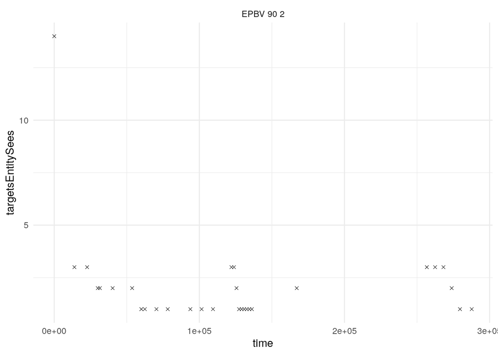

```r
library(ggplot2)

losPlot <- entityTrueLos %>%
  dplyr::left_join(x = .,
                   y = dplyr::select(.data = humanNameToSensor,
                                     entityId,
                                     shortName),
                   by = c("entityId"="entityId")) %>%
  dplyr::filter(shortName == "EPBV 90 2") %>%
  ggplot2::ggplot(data = .) +
  ggplot2::geom_point(mapping = aes(x = time,
                                    y = targetsEntitySees),
                      stroke = 0.15,
                      shape = 4) +
  ggplot2::facet_wrap(~shortName) +
  ggplot2::theme_minimal()

losPlot
```

# Produce Acquisitions by Sensor - Target Pair

## What **HAS** EPBV 90 2 Seen Over Time

Similar to the LOS data, lets see what the EPBV 90 2 has sensed over time.

Note, it appears `senderId`==`sensorId`

```r
entity_epbv_90_2_Acq <- sensorAcq %>%
  dplyr::select(sensorId,
                entityId,
                targetId,
                time,
                detectionLevel,
                previousDetectionLevel,
                timeToDetection) %>%
  dplyr::filter(sensorId %in% entity_epbv_90_2$sensorId)

entity_epbv_90_2_Acq
```

```
## # A tibble: 257 x 7
##    sensorId     entityId     targetId      time detectionLevel  previousDetecti…
##    <chr>        <chr>        <chr>        <int> <chr>           <chr>
##  1 b4b94b73-5a… 164684be-23… 71bd950b-70…    20 SENSOR_NODETEC… SENSOR_NODETECT…
##  2 f9421687-36… 164684be-23… 71bd950b-70…    20 SENSOR_NODETEC… SENSOR_NODETECT…
##  3 b4b94b73-5a… 164684be-23… d4aa2300-ce…    20 SENSOR_CORRECT… SENSOR_NODETECT…
##  4 6ef0c641-66… 164684be-23… 2a1f2f19-fd…    20 SENSOR_NODETEC… SENSOR_NODETECT…
##  5 6ef0c641-66… 164684be-23… 0e95015f-00…    20 SENSOR_NODETEC… SENSOR_NODETECT…
##  6 6ef0c641-66… 164684be-23… 164684be-23…    20 SENSOR_CORRECT… SENSOR_NODETECT…
##  7 f9421687-36… 164684be-23… 2a1f2f19-fd…    20 SENSOR_CLASSIF… SENSOR_NODETECT…
##  8 f9421687-36… 164684be-23… 0e95015f-00…    20 SENSOR_NODETEC… SENSOR_NODETECT…
##  9 b4b94b73-5a… 164684be-23… 2a1f2f19-fd…    20 SENSOR_CORRECT… SENSOR_NODETECT…
## 10 f9421687-36… 164684be-23… d4aa2300-ce…    20 SENSOR_CORRECT… SENSOR_NODETECT…
## # … with 247 more rows, and 1 more variable: timeToDetection <dbl>
```

Now that we have all of the observations for the EPBV 90 2, lets see only those times when targets are acquired:

```r
entity_epbv_90_2_Acq_detection <- entity_epbv_90_2_Acq %>%
  dplyr::filter(detectionLevel != "SENSOR_NODETECTION")
```

```r
tempDetected <- entity_epbv_90_2_Acq_detection %>%
  dplyr::left_join(x = .,
                   y = dplyr::distinct(.data = dplyr::select(.data = humanNameToSensor,
                                                             entityId,
                                                             shortName),
                                       entityId,
                                       shortName),
                   by = c("entityId"="entityId")) %>%
  dplyr::select(shortName,
                entityId,
                sensorId,
                targetId,
                time,
                detectionLevel,
                previousDetectionLevel,
                timeToDetection) %>%
    dplyr::distinct(shortName,entityId,time,targetId) %>%
    dplyr::group_by(shortName,entityId,time) %>%
  dplyr::summarise(targetsEntityAcquires = dplyr::n()) %>%
  dplyr::ungroup()
```

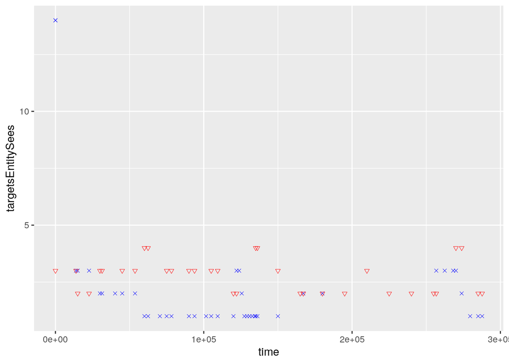

```r
tempCombined <- entityTrueLos %>%
  dplyr::left_join(x = .,
                   y = dplyr::select(.data = humanNameToSensor,
                                     entityId,
                                     shortName),
                   by = c("entityId"="entityId")) %>%
  dplyr::filter(shortName == "EPBV 90 2") %>%
  dplyr::ungroup() %>%
  dplyr::full_join(x = .,
                   y = dplyr::select(.data = tempDetected,
                                           entityId,
                                           time,
                                           targetsEntityAcquires),
                   by = c("entityId"="entityId","time"="time"))

tempCombined %>%
  dplyr::distinct(entityId,time,targetsEntitySees,shortName,targetsEntityAcquires) %>%
  dplyr::arrange(time) %>%
  dplyr::mutate(
    targetsEntitySees = dplyr::case_when(
      is.na(targetsEntitySees) ~ dplyr::lag(targetsEntitySees),
      TRUE ~ targetsEntitySees),
    shortName = dplyr::case_when(
      is.na(shortName) ~ dplyr::lag(shortName),
      TRUE ~ shortName),
    targetsEntityAcquires = dplyr::case_when(
    is.na(targetsEntityAcquires) ~ dplyr::lag(targetsEntityAcquires),
    TRUE ~ targetsEntityAcquires)) %>%
  dplyr::arrange(time) %>%
  ggplot2::ggplot(data = .) +
  ggplot2::geom_point(mapping = aes(x = time,
                                    y = targetsEntitySees),
                      stroke = 0.25,
                      shape = 4,
                      color = "blue") +
  ggplot2::geom_point(mapping = aes(x = time,
                                    y = targetsEntityAcquires),
                      stroke = 0.25,
                      shape = 25,
                      color = "red")
```

```r
entitySensorMapping$SensorDescription
```

```
## # A tibble: 30 x 3
##    sensorId                             acquireSensorType        magnification
##    <chr>                                <chr>                    <chr>
##  1 6ef0c641-6693-46ad-943b-203a7792d849 tankDaySight_sensor      FOV_W
##  2 b4b94b73-5a4d-4a53-a73d-13d70259a895 7x50Bino_sensor          FOV_S
##  3 f9421687-36ca-4f5e-9993-481d7de7f0f2 CdrLdrVisionBlock_sensor FOV_S
##  4 c96a7fe4-8d17-40f0-ada0-b92f7c713cfa tankDaySight_sensor      FOV_W
##  5 a826c760-8121-412a-a865-82dd1341a4b0 7x50Bino_sensor          FOV_S
##  6 d49c94fa-c76a-4ba9-b74f-528436a43c55 CdrLdrVisionBlock_sensor FOV_S
##  7 5f32bf10-054e-4204-8184-c2d0c5a530ce heloDaySight_sensor      FOV_W
##  8 0e79e63f-5bfb-4522-8ead-deedf025b479 7x50Bino_sensor          FOV_S
##  9 f5c75e3f-4de2-48c2-b824-f57ae953f867 unaidedEye_sensor        FOV_S
## 10 f23a9fc9-c291-4b9f-babe-1d151ce625e3 heloDaySight_sensor      FOV_W
## # … with 20 more rows
```

```r
entitySensorMapping$EntityIdToName
```

```
## # A tibble: 15 x 2
##    entityId                   source
##    <chr>                      <chr>
##  1 164684be-2368-405a-b11f-3… BLUEFORCE/BLUEFORCE/1.MECHBN/15.RECCECOY/151.RECC…
##  2 71bd950b-70ab-493c-8bfd-0… BLUEFORCE/BLUEFORCE/1.MECHBN/15.RECCECOY/151.RECC…
##  3 2a1f2f19-fd75-43af-940e-7… BLUEFORCE/BLUEFORCE/1.MECHBN/15.RECCECOY/151.RECC…
##  4 0e95015f-006e-448b-9431-7… BLUEFORCE/BLUEFORCE/1.MECHBN/15.RECCECOY/151.RECC…
##  5 d4aa2300-ceee-4677-acaa-9… BLUEFORCE/BLUEFORCE/1.MECHBN/15.RECCECOY/151.RECC…
##  6 31fe0957-0ba8-4a73-8470-5… BLUEFORCE/BLUEFORCE/1.MECHBN/15.RECCECOY/15.RADIO…
##  7 a364afbc-e0fb-4d0a-a8bd-7… REDFORCE/REDFORCE/1.MLRSBTY/BM30 6
##  8 23a15820-4a7a-4e2d-ad6a-7… REDFORCE/REDFORCE/1.MLRSBTY/BM30 1
##  9 fc58e557-f4ad-4353-a186-1… REDFORCE/REDFORCE/1.MLRSBTY/BM30 5
## 10 22d3b6e3-732d-4e69-982e-9… REDFORCE/REDFORCE/1.EW/JAMMER 1
## 11 11dc4f05-80b6-4f5c-a14a-7… REDFORCE/REDFORCE/1.MLRSBTY/BM30 3
## 12 aefaa978-c4f5-42ca-bd7f-9… BLUEFORCE/BLUEFORCE/1.MECHBN/1.MECHBN CDR
## 13 5c1c0ee5-d703-4b8a-ab5a-5… REDFORCE/REDFORCE/1.MLRSBTY/BM30 2
## 14 a8cfb96c-e7f8-4b7c-9784-0… REDFORCE/REDFORCE/1.MLRSBTY/BM30 4
## 15 0d14b64f-4301-4872-b188-e… BLUEFORCE/BLUEFORCE/1.MECHBN/15.RECCECOY/15.RECCE…
```

```r
entitySensorMapping$EntityIdToName
```

```
## # A tibble: 15 x 2
##    entityId                   source
##    <chr>                      <chr>
##  1 164684be-2368-405a-b11f-3… BLUEFORCE/BLUEFORCE/1.MECHBN/15.RECCECOY/151.RECC…
##  2 71bd950b-70ab-493c-8bfd-0… BLUEFORCE/BLUEFORCE/1.MECHBN/15.RECCECOY/151.RECC…
##  3 2a1f2f19-fd75-43af-940e-7… BLUEFORCE/BLUEFORCE/1.MECHBN/15.RECCECOY/151.RECC…
##  4 0e95015f-006e-448b-9431-7… BLUEFORCE/BLUEFORCE/1.MECHBN/15.RECCECOY/151.RECC…
##  5 d4aa2300-ceee-4677-acaa-9… BLUEFORCE/BLUEFORCE/1.MECHBN/15.RECCECOY/151.RECC…
##  6 31fe0957-0ba8-4a73-8470-5… BLUEFORCE/BLUEFORCE/1.MECHBN/15.RECCECOY/15.RADIO…
##  7 a364afbc-e0fb-4d0a-a8bd-7… REDFORCE/REDFORCE/1.MLRSBTY/BM30 6
##  8 23a15820-4a7a-4e2d-ad6a-7… REDFORCE/REDFORCE/1.MLRSBTY/BM30 1
##  9 fc58e557-f4ad-4353-a186-1… REDFORCE/REDFORCE/1.MLRSBTY/BM30 5
## 10 22d3b6e3-732d-4e69-982e-9… REDFORCE/REDFORCE/1.EW/JAMMER 1
## 11 11dc4f05-80b6-4f5c-a14a-7… REDFORCE/REDFORCE/1.MLRSBTY/BM30 3
## 12 aefaa978-c4f5-42ca-bd7f-9… BLUEFORCE/BLUEFORCE/1.MECHBN/1.MECHBN CDR
## 13 5c1c0ee5-d703-4b8a-ab5a-5… REDFORCE/REDFORCE/1.MLRSBTY/BM30 2
## 14 a8cfb96c-e7f8-4b7c-9784-0… REDFORCE/REDFORCE/1.MLRSBTY/BM30 4
## 15 0d14b64f-4301-4872-b188-e… BLUEFORCE/BLUEFORCE/1.MECHBN/15.RECCECOY/15.RECCE…
```

```r
entitySensorMapping$SensorToEntityId
```

```
## # A tibble: 30 x 2
##    sensorId                             entityId
##    <chr>                                <chr>
##  1 6ef0c641-6693-46ad-943b-203a7792d849 164684be-2368-405a-b11f-327d41a58665
##  2 b4b94b73-5a4d-4a53-a73d-13d70259a895 164684be-2368-405a-b11f-327d41a58665
##  3 f9421687-36ca-4f5e-9993-481d7de7f0f2 164684be-2368-405a-b11f-327d41a58665
##  4 c96a7fe4-8d17-40f0-ada0-b92f7c713cfa 71bd950b-70ab-493c-8bfd-0f2060886a83
##  5 a826c760-8121-412a-a865-82dd1341a4b0 71bd950b-70ab-493c-8bfd-0f2060886a83
##  6 d49c94fa-c76a-4ba9-b74f-528436a43c55 71bd950b-70ab-493c-8bfd-0f2060886a83
##  7 5f32bf10-054e-4204-8184-c2d0c5a530ce 2a1f2f19-fd75-43af-940e-7b8c560ed463
##  8 0e79e63f-5bfb-4522-8ead-deedf025b479 0e95015f-006e-448b-9431-72bf660f0edd
##  9 f5c75e3f-4de2-48c2-b824-f57ae953f867 0e95015f-006e-448b-9431-72bf660f0edd
## 10 f23a9fc9-c291-4b9f-babe-1d151ce625e3 d4aa2300-ceee-4677-acaa-9d43c078cff9
## # … with 20 more rows
```